# Linear Regression Fundamentals

Dr. Lucy D’Agostino McGowan

## Before You Fit a Model

📖 **Understand the content matter**  
As a statistician I collaborate frequently with subject matter experts to ensure that I understand the context of the problem at hand.

❓ **Understand the objective**  
It is crucial to understand what the objectives are. Ideally, these are set a priori, or if exploratory analyses are being done that is very explicit from beginning to end.

## Before You Fit a Model

📏 **Understand where the data came from**  
Was this observational or experimental data? Is any data missing? What are the units? Are there data entry issues?

🧹 **Get the data into a tidy, analyzable form**  
Often we get data in a form that is not easily analyzable. In this class, we will be focusing *mostly* on statistical methodology once the data *is* in an analyzable format, but just because it is analyzable doesn’t mean the analysis choice is obvious.

## Before You Fit a Model

💃 **Determine the appropriate model**  
In this class we are focusing on *Linear Models*. Linear models are not always appropriate. You must examine your data to determine whether a linear model is a good choice.

## Is a Linear Model Appropriate?

- Outcome variable, $y$ is continuous
- Explanatory variable(s), $X = \{X_1, ..., X_p\}$ can take any form
- Observations are independent
- The residuals are homoscedastic (Equal variance)
- The residuals are normally distributed
- The relationship between $X$ and $y$ is linear

# Statistics with Matrices

## Calculating a sample average

$$\bar{Y}=\frac{1}{N}\sum_{i=1}^NY_i$$

How could we write this using matrices?

## Calculating a sample average

$$\mathbf{A} = \begin{bmatrix}1 \\ 1 \\ \vdots \\ 1\end{bmatrix}$$

## Calculating a sample average

$$\frac{1}{N}\mathbf{A}^TY = \frac{1}{N}\begin{bmatrix}1 & 1 & ... & 1\end{bmatrix}\begin{bmatrix}Y_1\\Y_2\\\vdots\\Y_n\end{bmatrix}=\bar{Y}$$

## In R

```r
set.seed(1)

y <- rnorm(100)
N <- length(y)
Y <- matrix(y, nrow = N)
A <- matrix(1, nrow = N)
t(A) %*% Y / N
```

```
          [,1]
[1,] 0.1088874
```

```r
mean(Y)
```

```
[1] 0.1088874
```

## Calculating a Variance

$$\frac{1}{N}\sum_{i=1}^N(Y_i-\bar{Y})^2$$

How could we write this using matrices

## Calculating a Variance

$$\mathbf{e} = \begin{bmatrix}Y_1 - \bar{Y}\\\vdots \\Y_N-\bar{Y}\end{bmatrix}, \frac{1}{N}\mathbf{e}^T\mathbf{e} = \frac{1}{N}\sum_{i=1}^N(Y_i-\bar{Y})^2$$

## In R

- Multiplying a transpose of a matrix with another matrix is very common
- Because R was made by and for statisticians, there is a function for this: `crossprod`

```r
crossprod(A, Y) / N
```

```
          [,1]
[1,] 0.1088874
```

## In R

- You can just put one matrix if you want the transpose of a matrix multiplied by itself

```r
Y_bar <- crossprod(A, Y) / N
e <- y - c(Y_bar)
crossprod(e) / N
```

```
          [,1]
[1,] 0.7986945
```

# Least Squares in Matrix Form

## The Linear Model

**Standard form:**
$$\mathbf{y} = \mathbf{X}\boldsymbol{\beta} + \boldsymbol{\varepsilon}$$

Where:

- $\mathbf{y}$ is an $n \times 1$ vector of responses
- $\mathbf{X}$ is an $n \times p$ design matrix
- $\boldsymbol{\beta}$ is a $p \times 1$ vector of parameters
- $\boldsymbol{\varepsilon}$ is an $n \times 1$ vector of errors

## The Design Matrix

**Simple linear regression:**
$$\mathbf{X} = \begin{bmatrix}
1 & x_1 \\
1 & x_2 \\
\vdots & \vdots \\
1 & x_n
\end{bmatrix}, \quad \boldsymbol{\beta} = \begin{bmatrix} \beta_0 \\ \beta_1 \end{bmatrix}$$

## The Design Matrix

**Multiple regression:**
$$\mathbf{X} = \begin{bmatrix}
1 & x_{11} & x_{12} & \cdots & x_{1p} \\
1 & x_{21} & x_{22} & \cdots & x_{2p} \\
\vdots & \vdots & \vdots & \ddots & \vdots \\
1 & x_{n1} & x_{n2} & \cdots & x_{np}
\end{bmatrix}$$

## What About Hats?

**Hat notation indicates estimates or predicted values**

**Parameters vs. Estimates:**

- $\beta_0, \beta_1$ = true (unknown) parameters
- $\hat{\beta}_0, \hat{\beta}_1$ = estimated parameters from data

**Observed vs. Predicted:**

- $y_i$ = observed response values
- $\hat{y}_i$ = predicted values from model

## What is a Residual?

**Definition:** A residual is the difference between an observed value and its predicted value from the model

Formula:

$$\hat\varepsilon_i = y_i-\hat{y}_i$$

## You Try: Calculating Residuals

**Problem:** Given the regression equation $\hat{y} = 2.3 + 1.5x$ and the data points below, calculate the residual for each observation:

| x | y | $\hat{y}$ | $\hat{\varepsilon}$ |
| --- | --- | --- | --- |
| 1 | 4.2 | ? | ? |
| 3 | 6.8 | ? | ? |
| 5 | 11.1 | ? | ? |

`04:00`

## Let’s Try It in R

**Problem:** Given the same regression equation $\hat{y} = 2.3 + 1.5x$ and $y = [4.2, 6.8, 11.1]$, $x = [1, 3, 5]$:

1. Put the x values in a design matrix called `X` and the outcome in a vector called `y`
2. Put the coefficients in a vector called `beta`
3. Multiply them to get $\hat{y}$
4. Subtract from `y` to get residuals

`04:00`

## Let’s Try It in R Solution

```r
# 1. Create design matrix X
X <- matrix(c(1, 1,
              1, 3,
              1, 5),
            byrow = TRUE, ncol = 2)
# Create y
y <- c(4.2, 6.8, 11.1)

# 2. Create beta vector
beta <- c(2.3, 1.5)

# 3. Calculate y_hat
y_hat <- X %*% beta

# 4. Calculate residuals
residuals <- y - y_hat

residuals
```

```
     [,1]
[1,]  0.4
[2,]  0.0
[3,]  1.3
```

## The Goal: Minimize Squared Errors

**Sum of squared errors:**

$$\text{SSE} = \sum_{i=1}^n (y_i - \hat{y}_i)^2 = \sum_{i=1}^n \hat\varepsilon_i^2$$

$$\text{SSE} = (\mathbf{y}- \mathbf{X}\boldsymbol\beta)^T(\mathbf{y}- \mathbf{X}\boldsymbol\beta)$$

## You Try

**Problem:** Verify that these two expressions for SSE are the same:

**Individual terms:**
$$\text{SSE} = \sum_{i=1}^{n} (y_i - \hat{y}_i)^2$$

**Matrix form:**
$$\text{SSE} = (\mathbf{y} - \mathbf{X}\boldsymbol{\beta})^T(\mathbf{y} - \mathbf{X}\boldsymbol{\beta})$$

**Task:** Expand the matrix form and show it equals the summation form

## Visualizing Squared Residuals

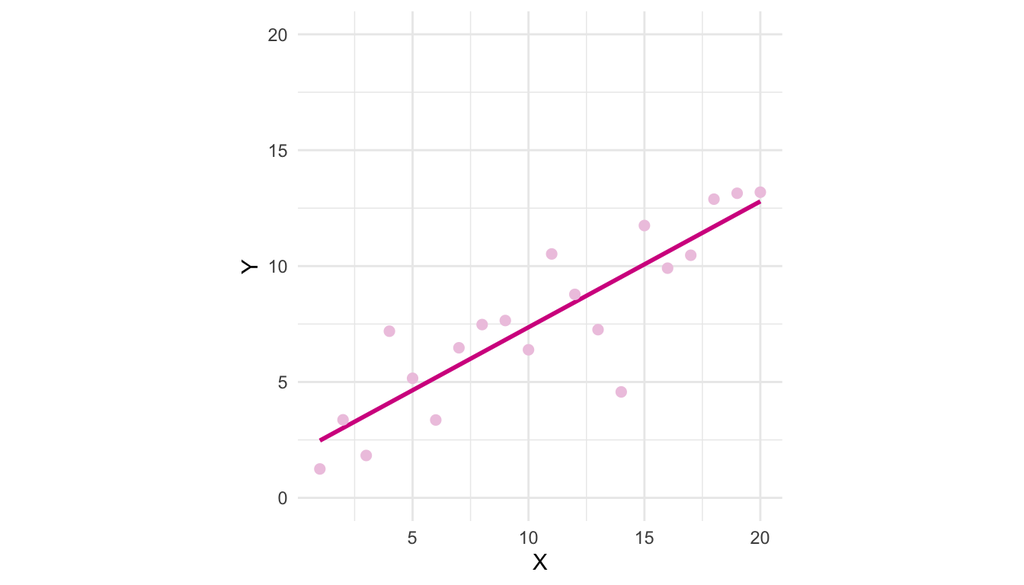

## Visualizing Squared Residuals

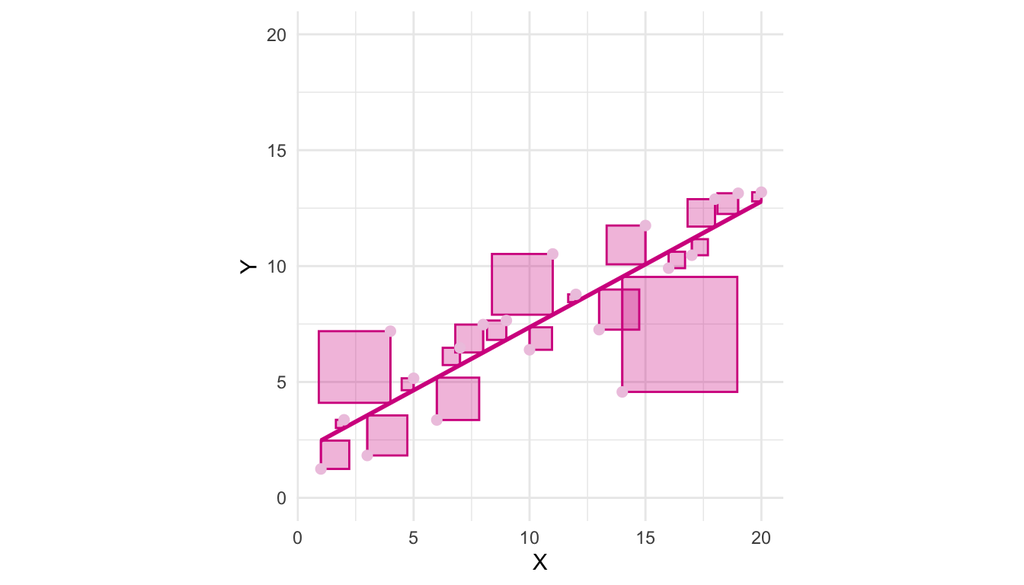

## Application Exercise

1. Go to lucy.shinyapps.io/least-squares/.
2. This shows a scatter plot of 10 data points with a line estimating the relationship between x and y. Drag the blue points to change the line.
3. See if you can find a line that minimizes the sum of square errors

`03:00`

# Geometric Interpretation of Least Squares

## What We’re Really Doing

**The regression equation:**
$$\mathbf{y} = \mathbf{X}\boldsymbol{\beta} + \boldsymbol{\varepsilon}$$

**The goal:** Find $\boldsymbol{\beta}$ that makes $\mathbf{X}\boldsymbol{\beta}$ as close as possible to $\mathbf{y}$

## Understanding the Vector Space

**If we have $n$ observations, we work in $n$-dimensional space**

**$\mathbf{y}$ is a vector with $n$ components (one value per observation)**

**$\mathbf{X}\boldsymbol{\beta}$ is also a vector with $n$ components (one prediction per observation)**

**Both vectors live in the same $n$-dimensional space**

## What is Column Space?

**In words:** All possible predictions your model can make

**Think of it as:** Every combination of your predictor variables

## Column Space with Numbers

**Your data:** $x = [1, 2, 3]$ with 3 observations

**Design matrix:** $\mathbf{X} = \begin{bmatrix} 1 & 1 \\ 1 & 2 \\ 1 & 3 \end{bmatrix}$

**Column space contains:** All vectors of the form $\beta_0 \begin{bmatrix} 1 \\ 1 \\ 1 \end{bmatrix} + \beta_1 \begin{bmatrix} 1 \\ 2 \\ 3 \end{bmatrix}$

## Examples of Vectors in Column Space

**Example 1:** Choose $\beta_0=0, \beta_1=2$ gives $[2, 4, 6]$

**In words:** Intercept = 0, slope = 2, so predictions are [2, 4, 6]

**Example 2:** Choose $\beta_0=5, \beta_1=0$ gives $[5, 5, 5]$

**In words:** Intercept = 5, slope = 0, so all predictions equal 5

## The Fundamental Problem

**Your actual observed data:** $\mathbf{y} = [2.1, 3.9, 5.8]$

**Question:** Is there some $\beta_0, \beta_1$ such that $\mathbf{X}\boldsymbol{\beta} = \mathbf{y}$ exactly?

**In other words:** Is $[2.1, 3.9, 5.8]$ exactly equal to $\beta_0[1,1,1] + \beta_1[1,2,3]$?

## Why We Usually Can’t Hit Exactly

- **Answer: Usually no!** Real data has irreducible error
- Your observed $\mathbf{y}$ typically doesn’t lie perfectly in the column space*
- **In words:** Your data points don’t lie exactly on any straight line

## The Geometric Solution

- Since we can’t hit $\mathbf{y}$ exactly, let’s get as close as possible
- Find the point in the column space that is closest to $\mathbf{y}$
- This closest point is the orthogonal projection of $\mathbf{y}$ onto the column space

## The Residual Vector

- **Definition:** $\hat\varepsilon = \mathbf{y} - \hat{\mathbf{y}}$
- **In words:** The difference between what we observed and what we predicted
- *This represents the part of $\mathbf{y}$ we cannot explain with our model*

## Key Geometric Property

- The residual vector is perpendicular to the column space
- **Mathematical notation:** $\hat\varepsilon \perp \text{Col}(\mathbf{X})$
- **Why this matters:** Perpendicularity guarantees we found the closest point

## Why Perpendicular Means Closest?

- Imagine dropping a ball onto a table from above
- The shortest path is straight down (perpendicular to the table)
- Any diagonal path would be longer
- The same principle applies in higher dimensions

## From Geometry to Algebra

- **Geometric fact:** $\hat\varepsilon \perp \text{Col}(\mathbf{X})$
- This means $\hat\varepsilon$ is perpendicular to every vector in the column space
- Since columns of $\mathbf{X}$ span the column space, $\hat\varepsilon$ is perpendicular to each column

## Mathematical Expression of Perpendicularity

**If $\mathbf{X} = [\mathbf{x}_1, \mathbf{x}_2, \ldots, \mathbf{x}_p]$, then:**

**$\mathbf{x}_1^T\hat\varepsilon = 0$, $\mathbf{x}_2^T\hat\varepsilon = 0$, …, $\mathbf{x}_p^T\hat\varepsilon = 0$**

**Stacking these equations gives us:** $\mathbf{X}^T\hat\varepsilon = \mathbf{0}$

## The Normal Equations

**Starting from:** $\mathbf{X}^T\hat\varepsilon = \mathbf{0}$

**Substitute $\hat\varepsilon = \mathbf{y} - \mathbf{X}\hat{\boldsymbol{\beta}}$:**
$$\mathbf{X}^T(\mathbf{y} - \mathbf{X}\hat{\boldsymbol{\beta}}) = \mathbf{0}$$

**In words:** “The residuals are perpendicular to every column of $\mathbf{X}$”

## You Try: Matrix Algebra

**Starting with:** $\mathbf{A}\mathbf{x} + \mathbf{b} = \mathbf{c}$

**Solve for $\mathbf{x}$ step by step:**

1. First, isolate the $\mathbf{A}\mathbf{x}$ term
2. Then multiply both sides by $\mathbf{A}^{-1}$ (on the left!)

`04:00`

## Expanding the Normal Equations

**Start with:** $\mathbf{X}^T(\mathbf{y} - \mathbf{X}\hat{\boldsymbol{\beta}}) = \mathbf{0}$

**Distribute:** $\mathbf{X}^T\mathbf{y} - \mathbf{X}^T\mathbf{X}\hat{\boldsymbol{\beta}} = \mathbf{0}$

**Move the second term to the right side:** $\mathbf{X}^T\mathbf{y} = \mathbf{X}^T\mathbf{X}\hat{\boldsymbol{\beta}}$

## Solving for Beta

**We have:** $\mathbf{X}^T\mathbf{X}\hat{\boldsymbol{\beta}} = \mathbf{X}^T\mathbf{y}$

**To solve for $\hat{\boldsymbol{\beta}}$, multiply both sides by $(\mathbf{X}^T\mathbf{X})^{-1}$:**

**Result:** $\hat{\boldsymbol{\beta}} = (\mathbf{X}^T\mathbf{X})^{-1}\mathbf{X}^T\mathbf{y}$

**This is the least squares solution!**

## The Hat Matrix

**Definition:** $\mathbf{H} = \mathbf{X}(\mathbf{X}^T\mathbf{X})^{-1}\mathbf{X}^T$

**What it does:** $\hat{\mathbf{y}} = \mathbf{H}\mathbf{y}$

**In words:** Takes your observed data and produces the closest possible predictions

**Nickname:** “Puts the hat on $\mathbf{y}$” to get $\hat{\mathbf{y}}$

## Hat Matrix Properties

**Symmetric:** $\mathbf{H}^T = \mathbf{H}$

**Idempotent:** $\mathbf{H}^2 = \mathbf{H}$

## You Try: Hat Matrix Property

**Verify that:** $\mathbf{H}^2 = \mathbf{H}$

**Hint:** Substitute the definition $\mathbf{H} = \mathbf{X}(\mathbf{X}^T\mathbf{X})^{-1}\mathbf{X}^T$ and multiply it out

**Remember:** $(\mathbf{A}^{-1})^{-1} = \mathbf{A}$

`03:00`

## Why “Least Squares”?

**We minimize:** $\sum_{i=1}^n (y_i - \hat{y}_i)^2$

**In words:** Sum of squared differences between observed and predicted

**This equals:** $||\mathbf{y} - \mathbf{X}\boldsymbol{\beta}||^2$

**In words:** Squared distance between the observed vector and prediction vector

## Key Geometric Insights

**1. Regression is projection:** Finding the closest point in the column space to $\mathbf{y}$

**2. Orthogonality is key:** Residuals perpendicular to column space guarantees minimum distance

**3. Hat matrix is the projection operator:** $\mathbf{H}$ projects onto column space

## You Try

**Try this in R:**  
1. `x <- 1:10; y <- 2*x + rnorm(10)`  
2. `X <- cbind(1, x)` # Design matrix  
3. `H <- X %*% solve(crossprod(X)) %*% t(X)` # Hat matrix  
4. Check: `all.equal(H %*% H, H)` # Verify idempotent  
5. `e <- y - H %*% y` # Residuals  
6. Check: `t(X) %*% e` # Should be approximately zero

`04:00`